# Step1. Generate MetaSpots

In this vignette we use Seurat v5 to create a Seurat object, aggregate data into MetaSpots (i.e., MetaCells) to reduce sparseness, and then run STEAM.

We use ranked gene lists from Open Targets (v.25.06) for Schizophrenia, SCZ, (MONDO_0005090), and the spatial transcriptomics dataset of the human dorsolateral prefrontal cortex (151673) from Maynard et al. (https://doi.org/10.1038/s41593-020-00787-0).

# 1 Load libraries

Load the necessary libraries.

```r
library(Seurat)
library(SeuratObject)
library(dplyr)
library(STEAM)
library(future)
```

# 2 Load data

Load data.

```r
se <- Load10X_Spatial(
  data.dir = "data/human_brain_cortex/",
  filename = "filtered_feature_bc_matrix.h5",
  assay = "Spatial",
  slice = "slice1"
)

se
```

```
## An object of class Seurat
## 33538 features across 3639 samples within 1 assay
## Active assay: Spatial (33538 features, 0 variable features)
##  1 layer present: counts
##  1 spatial field of view present: slice1
```

Filter data.

```r
# Get raw count matrix
counts <- GetAssayData(se, slot = "counts")

# Apply gene filters
genes_to_keep <- rownames(counts)[
  Matrix::rowSums(counts) >= 100 &     # Total UMI count per gene
  Matrix::rowSums(counts > 0) >= 5     # Expressed in ≥5 spots
]

# Apply spot (cell) filters
spots_to_keep <- colnames(counts)[
  Matrix::colSums(counts) >= 500       # Total UMIs per spot
]

# Subset the Seurat object with filtered genes and spots
se <- subset(se, features = genes_to_keep, cells = spots_to_keep)
se
```

```
## An object of class Seurat
## 11381 features across 3632 samples within 1 assay
## Active assay: Spatial (11381 features, 0 variable features)
##  1 layer present: counts
##  1 spatial field of view present: slice1
```

Load cluster annotations.

```r
seurat_clusters <- read.csv(file = "data/human_brain_cortex/seurat_clusters.csv", sep = ";")
```

Check cluster annotations and Seurat object barcode names.

```r
head(seurat_clusters)
```

```
##                Barcode seurat_clusters
## 1 TTATTTCATCCCAAAC-1_1               5
## 2 GAGCGCTATGTCAGGC-1_1               5
## 3 CTTCGTGCCCGCATCG-1_1               5
## 4 GACGGGATGTCTTATG-1_1               5
## 5 GGCGAGCATCGAGGAC-1_1               5
## 6 CGCGTGCTATCAACGA-1_1               5
```

```r
head(se[[]])
```

```
##                       orig.ident nCount_Spatial nFeature_Spatial
## AAACAAGTATCTCCCA-1 SeuratProject           8458             3586
## AAACAATCTACTAGCA-1 SeuratProject           1667             1150
## AAACACCAATAACTGC-1 SeuratProject           3769             1960
## AAACAGAGCGACTCCT-1 SeuratProject           5433             2424
## AAACAGCTTTCAGAAG-1 SeuratProject           4278             2264
## AAACAGGGTCTATATT-1 SeuratProject           4004             2178
```

Update cluster annotations to match the Seurat objects barcodes.

```r
seurat_clusters$Barcode <- sub("_1$", "", seurat_clusters$Barcode)
head(seurat_clusters)
```

```
##              Barcode seurat_clusters
## 1 TTATTTCATCCCAAAC-1               5
## 2 GAGCGCTATGTCAGGC-1               5
## 3 CTTCGTGCCCGCATCG-1               5
## 4 GACGGGATGTCTTATG-1               5
## 5 GGCGAGCATCGAGGAC-1               5
## 6 CGCGTGCTATCAACGA-1               5
```

Add annotations to the Seurat object.

```r
rownames(seurat_clusters) <- seurat_clusters$Barcode
seurat_clusters$Barcode <- NULL
se$seurat_clusters <- seurat_clusters
se$seurat_clusters_plot <- as.factor(se$seurat_clusters) # For plotting of spatial structures
head(se[[]])
```

```
##                       orig.ident nCount_Spatial nFeature_Spatial
## AAACAAGTATCTCCCA-1 SeuratProject           8458             3586
## AAACAATCTACTAGCA-1 SeuratProject           1667             1150
## AAACACCAATAACTGC-1 SeuratProject           3769             1960
## AAACAGAGCGACTCCT-1 SeuratProject           5433             2424
## AAACAGCTTTCAGAAG-1 SeuratProject           4278             2264
## AAACAGGGTCTATATT-1 SeuratProject           4004             2178
##                    seurat_clusters seurat_clusters_plot
## AAACAAGTATCTCCCA-1               4                    4
## AAACAATCTACTAGCA-1               5                    5
## AAACACCAATAACTGC-1               7                    7
## AAACAGAGCGACTCCT-1               2                    2
## AAACAGCTTTCAGAAG-1               8                    8
## AAACAGGGTCTATATT-1               3                    3
```

Plot seurat_clusters

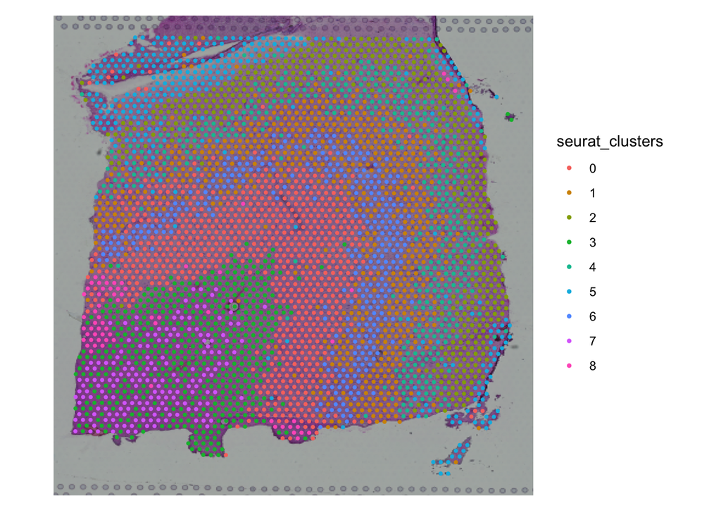

```r
SpatialDimPlot(se,group.by = "seurat_clusters")
```

Check number of cell per cell type of the cluster annotation you want to create MetaSpots from.

```r
table(se$seurat_clusters)
```

```
##
##   0   1   2   3   4   5   6   7   8
## 680 630 525 486 427 341 305 175  63
```

IMPORTANT: if you have clustered with e.g., Seurat, you need to copy the ‘seurat_clusters’ metadata into a new metadata slot called ‘cluster_anno’ for downstream processing!

```r
se$cluster_anno <- se$seurat_clusters
table(se$cluster_anno)
```

```
##
##   0   1   2   3   4   5   6   7   8
## 680 630 525 486 427 341 305 175  63
```

# 3 Generat MetaSpot clusters

Here we want to generate MetaSpots from the cluster annotation ‘cluster_anno’. The generate_metacell_clusters function subsets all selected clusters into separate Seurat objects and then uses NormalizeData, FindVariableFeatures, ScaleData, RunPCA and FindNeighbors on each and saving the to a list. For each Seurat in the list the optimal clustering resolution setting test iterated using the FindClusters function, starting at a user given inital resolution (initial_resolution) and moving by 0.1 until the average number of cells per cluster (future MetaSpot) is > 10 (num_cells_per_metacell). The generate_metacell_clusters iterations then reduces the clustering resolution with 0.1 if the average number of cells per cluster (future MetaSpot) is < 10 (num_cells_per_metacell), and then stops.

Please note that if the desired number of average cells per cluster is not possible the reach, the function will stall out. If that happens try using +/- 1 desired number of average cells per cluster and re-run.

```r
plan("sequential")

metaspots <- generate_metacell_clusters(
   se = se,
   cluster_anno = "cluster_anno",
   num_cells_per_metacell = 10,
   pca_dims = 10,
   initial_resolution = 0.1
 )
```

```
## [1] "Removed cell types with too few cells:"
## character(0)
```

```
##
## Processing cell type: 4
```

```
##
## Processing cell type: 5
```

```
##
## Processing cell type: 7
```

```
##
## Processing cell type: 2
```

```
##
## Processing cell type: 8
```

```
##
## Processing cell type: 3
```

```
##
## Processing cell type: 0
```

```
##
## Processing cell type: 1
```

```
##
## Processing cell type: 6
```

Lets sort and investigate the output and look at the distribution of the number of units (spots or cells) per cluster that we will aggregate into MetaSpots. Watch out for extremely skewed distributions. If that happens, investigate if other QC filtering settings after subsampling might help.

Sort the MetaSpots alphabetically.

```r
metaspots <- sort_metacells(se, metacells = metaspots, cluster_anno = "cluster_anno")
```

Plot the MetaCluster distribution

```
## Number of clusters for 0 : 68
## Cluster distribution:
## clusters
##  0  1  2  3  4  5  6  7  8  9 10 11 12 13 14 15 16 17 18 19 20 21 22 23 24 25
## 34 23 22 22 21 19 18 17 17 17 16 16 15 15 14 14 14 14 14 14 14 13 12 12 12 11
## 26 27 28 29 30 31 32 33 34 35 36 37 38 39 40 41 42 43 44 45 46 47 48 49 50 51
## 10 10 10 10  9  9  9  9  8  8  8  7  7  7  7  7  7  7  6  6  6  6  6  6  5  5
## 52 53 54 55 56 57 58 59 60 61 62 63 64 65 66 67
##  5  5  4  4  4  3  3  5  3  3  2  2  2  5  3  2
```

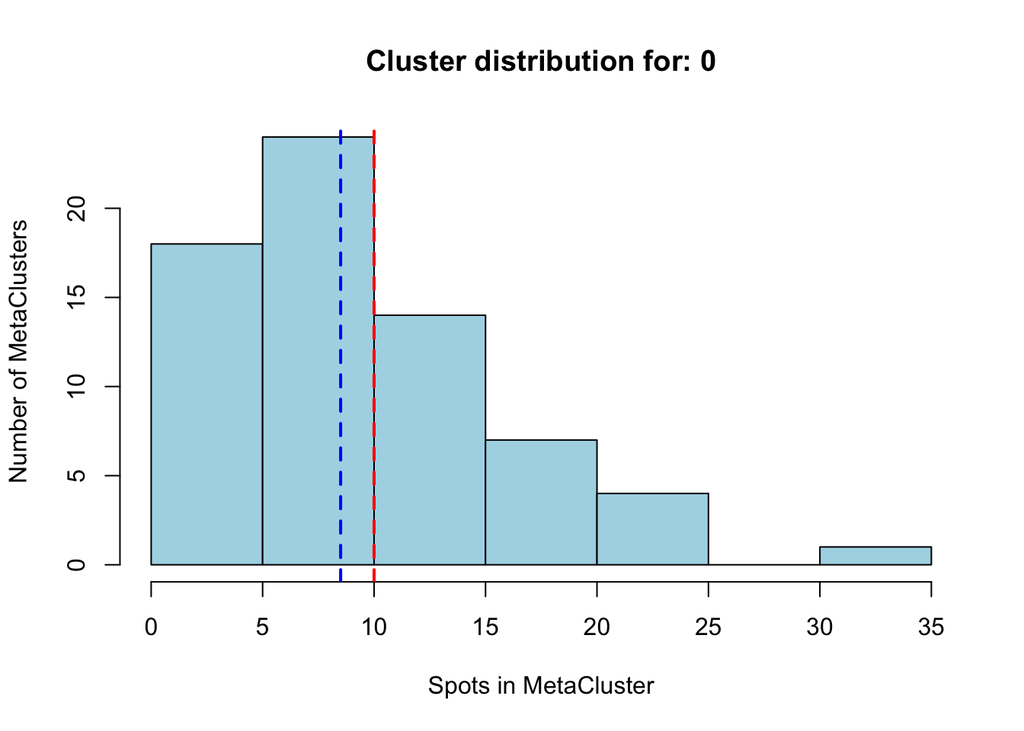

```
## ________________________________________________________________________________
## Number of clusters for 1 : 63
## Cluster distribution:
## clusters
##  0  1  2  3  4  5  6  7  8  9 10 11 12 13 14 15 16 17 18 19 20 21 22 23 24 25
## 27 25 20 21 18 18 18 17 17 16 16 15 15 15 14 14 14 13 13 12 12 12 12 12 11 11
## 26 27 28 29 30 31 32 33 34 35 36 37 38 39 40 41 42 43 44 45 46 47 48 49 50 51
## 11 11 11 11 12 10 10 10  9  8  8  8  8  7  7  7  7  6  5  5  4  4  5  4  3  3
## 52 53 54 55 56 57 58 59 60 61 62
##  5  3  3  3  2  2  2  2  2  2  2
```

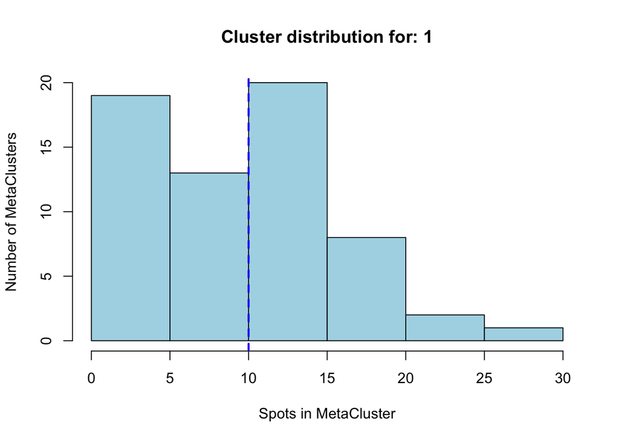

```
## ________________________________________________________________________________
## Number of clusters for 2 : 49
## Cluster distribution:
## clusters
##  0  1  2  3  4  5  6  7  8  9 10 11 12 13 14 15 16 17 18 19 20 21 22 23 24 25
## 22 21 20 19 19 19 19 19 17 17 17 16 16 16 15 14 12 12 13 12 12 12 12 11 10 10
## 26 27 28 29 30 31 32 33 34 35 36 37 38 39 40 41 42 43 44 45 46 47 48
##  8  8  7  7  7  7  6  6  6  6  6  6  5  5  5  5  4  4  3  3  4  2  3
```

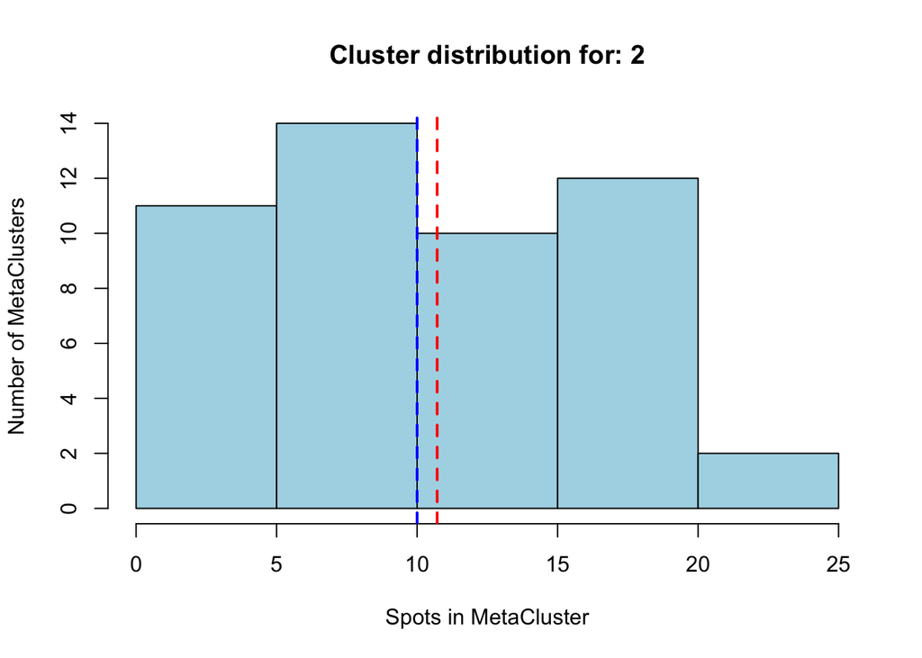

```
## ________________________________________________________________________________
## Number of clusters for 3 : 47
## Cluster distribution:
## clusters
##  0  1  2  3  4  5  6  7  8  9 10 11 12 13 14 15 16 17 18 19 20 21 22 23 24 25
## 22 22 22 18 16 18 15 15 15 15 15 14 15 13 13 13 13 12 12 12 12 11 10 10 11 10
## 26 27 28 29 30 31 32 33 34 35 36 37 38 39 40 41 42 43 44 45 46
##  9  8  8  8  8  7  7  6  6  5  5  6  4  4  5  4  3  3  2  2  2
```

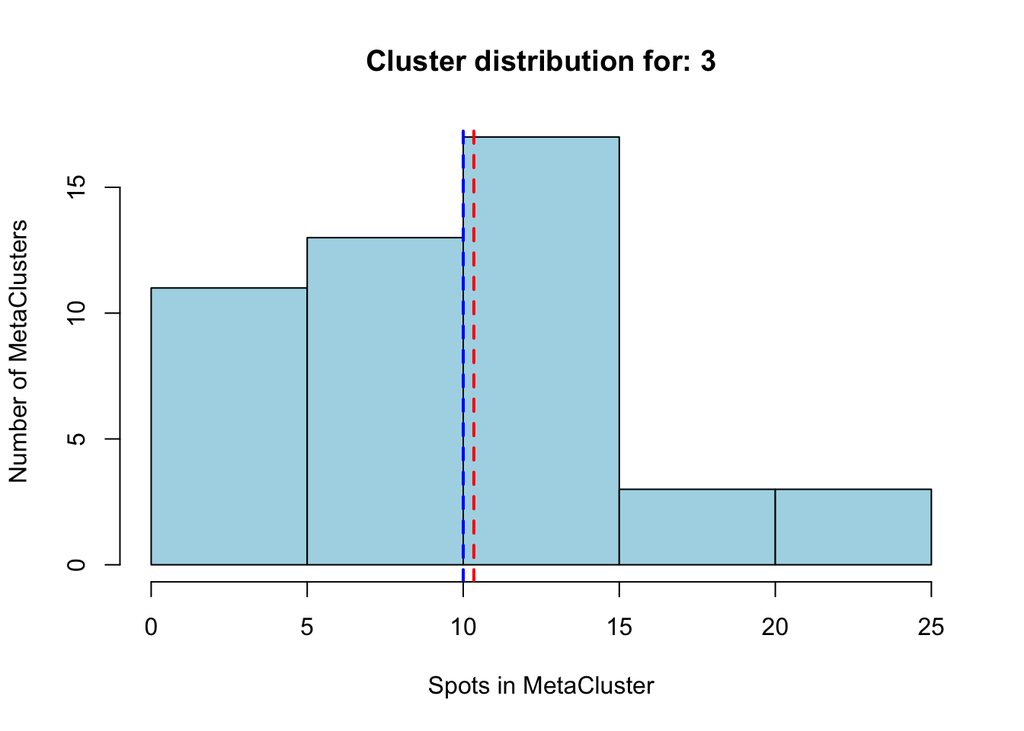

```
## ________________________________________________________________________________
## Number of clusters for 4 : 40
## Cluster distribution:
## clusters
##  0  1  2  3  4  5  6  7  8  9 10 11 12 13 14 15 16 17 18 19 20 21 22 23 24 25
## 27 26 25 22 21 17 17 16 15 15 15 13 12 12 11 11 10 10  9  9  9  9  8  8  7  7
## 26 27 28 29 30 31 32 33 34 35 36 37 38 39
##  7  7  6  4  5  4  5  5  5  4  4  2  3  5
```

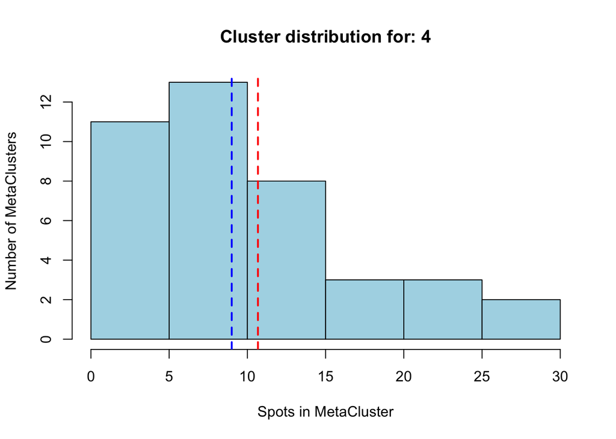

```
## ________________________________________________________________________________
## Number of clusters for 5 : 34
## Cluster distribution:
## clusters
##  0  1  2  3  4  5  6  7  8  9 10 11 12 13 14 15 16 17 18 19 20 21 22 23 24 25
## 29 25 21 19 18 18 18 17 15 14 13 13 11 11 11 10 10  9  8  6  5  5  4  4  4  3
## 26 27 28 29 30 31 32 33
##  5  3  2  2  2  2  2  2
```

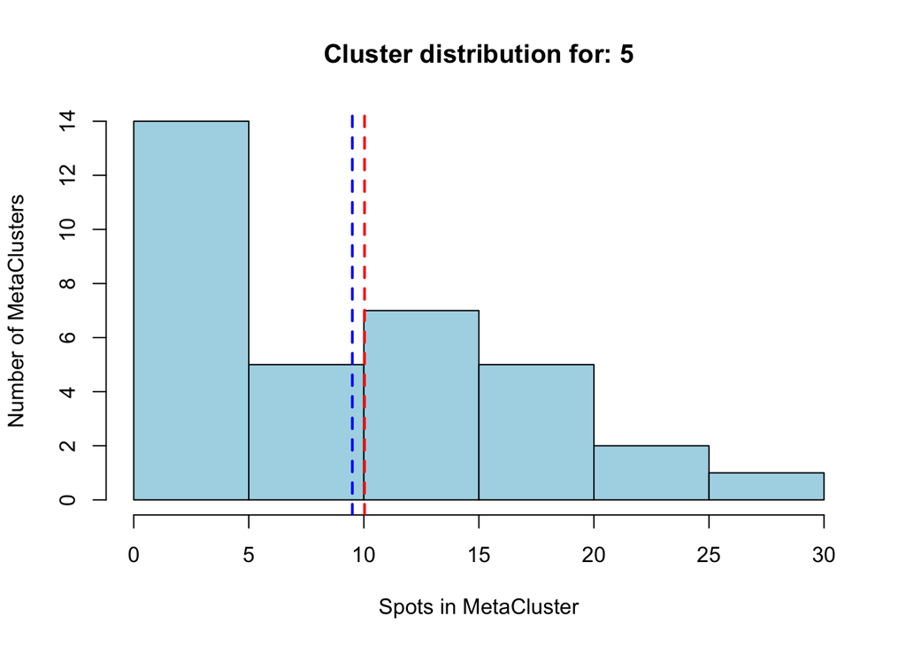

```
## ________________________________________________________________________________
## Number of clusters for 6 : 30
## Cluster distribution:
## clusters
##  0  1  2  3  4  5  6  7  8  9 10 11 12 13 14 15 16 17 18 19 20 21 22 23 24 25
## 27 26 24 22 19 19 16 15 13 11 11 10  9  9  9  7  9  6  6  6  5  3  3  3  3  4
## 26 27 28 29
##  3  2  2  3
```

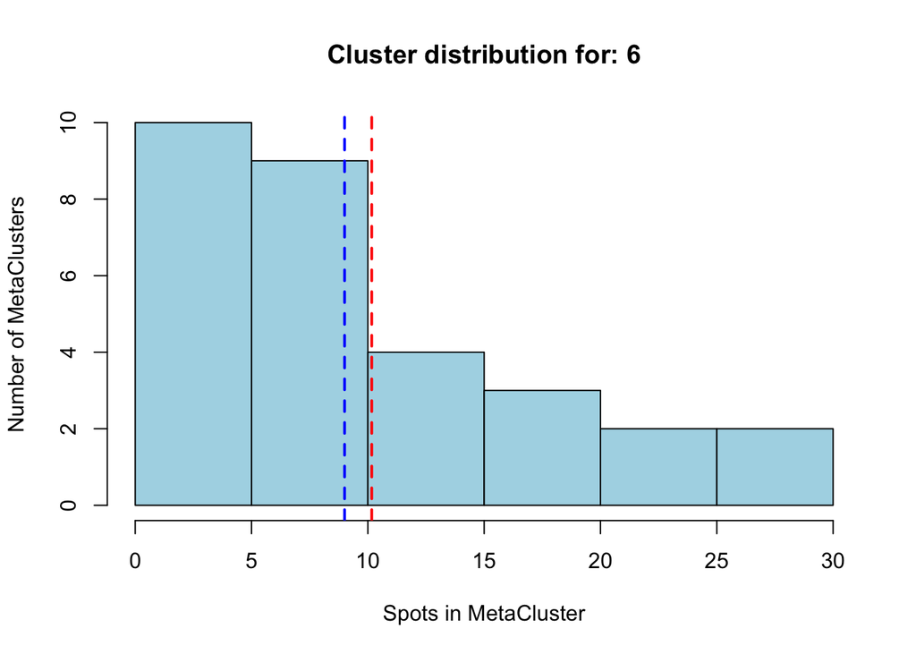

```
## ________________________________________________________________________________
## Number of clusters for 7 : 17
## Cluster distribution:
## clusters
##  0  1  2  3  4  5  6  7  8  9 10 11 12 13 14 15 16
## 36 20 17 17 16 11 10 10  6  6  5  5  3  3  5  3  2
```

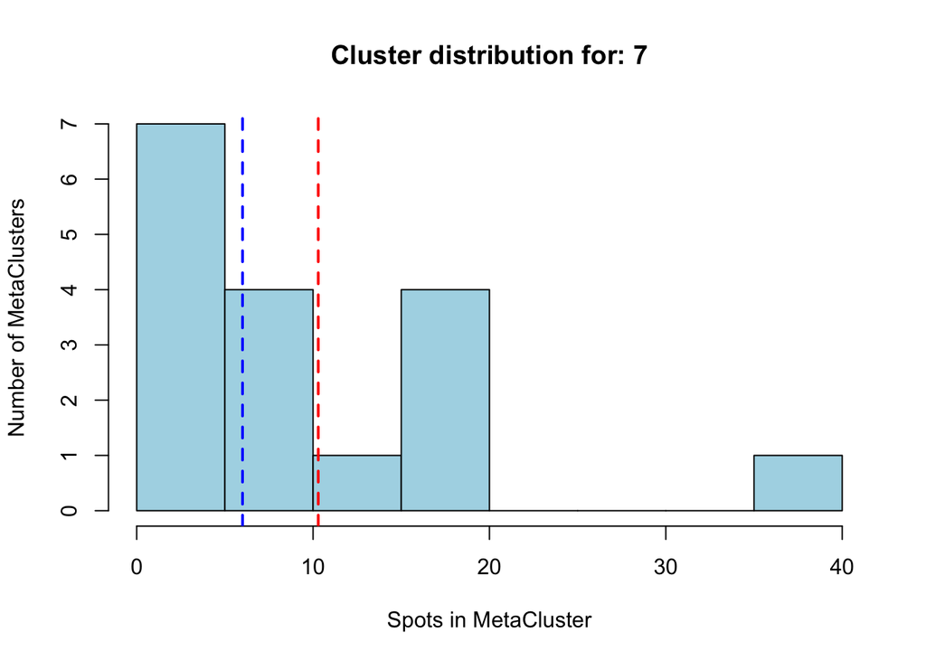

```
## ________________________________________________________________________________
## Number of clusters for 8 : 4
## Cluster distribution:
## clusters
##  0  1  2  3
## 28 20 13  2
```

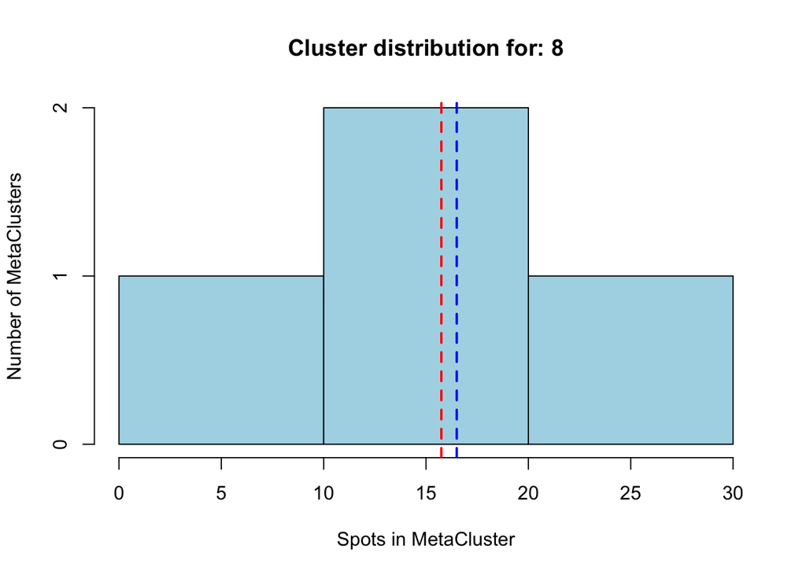

```
## ________________________________________________________________________________
```

```r
plot_metaclusters(metaspots, show_mean = T, show_median = T)
```

# 4 Aggregate MetaSpot clusters

Now, let’s aggregates the expression data across clusters (MetaSpots) by summing counts within each cluster of each cell type, and create a MetaSpot Seurat object!

```r
metaspot_seurat <- aggregate_metacells(cell_type_clusters = metaspots$metacells, cluster_col = "cluster_anno")
table(metaspot_seurat$cluster_anno)
```

```
##
##  0  1  2  3  4  5  6  7  8
## 68 63 49 47 40 34 30 17  4
```

```r
metaspot_seurat
```

```
## An object of class Seurat
## 11381 features across 352 samples within 1 assay
## Active assay: RNA (11381 features, 0 variable features)
##  9 layers present: counts.1.1.1.1.1.1.1.1, counts.2, counts.2.1, counts.2.1.1, counts.2.1.1.1, counts.2.1.1.1.1, counts.2.1.1.1.1.1, counts.2.1.1.1.1.1.1, counts.2.1.1.1.1.1.1.1
```

Check results

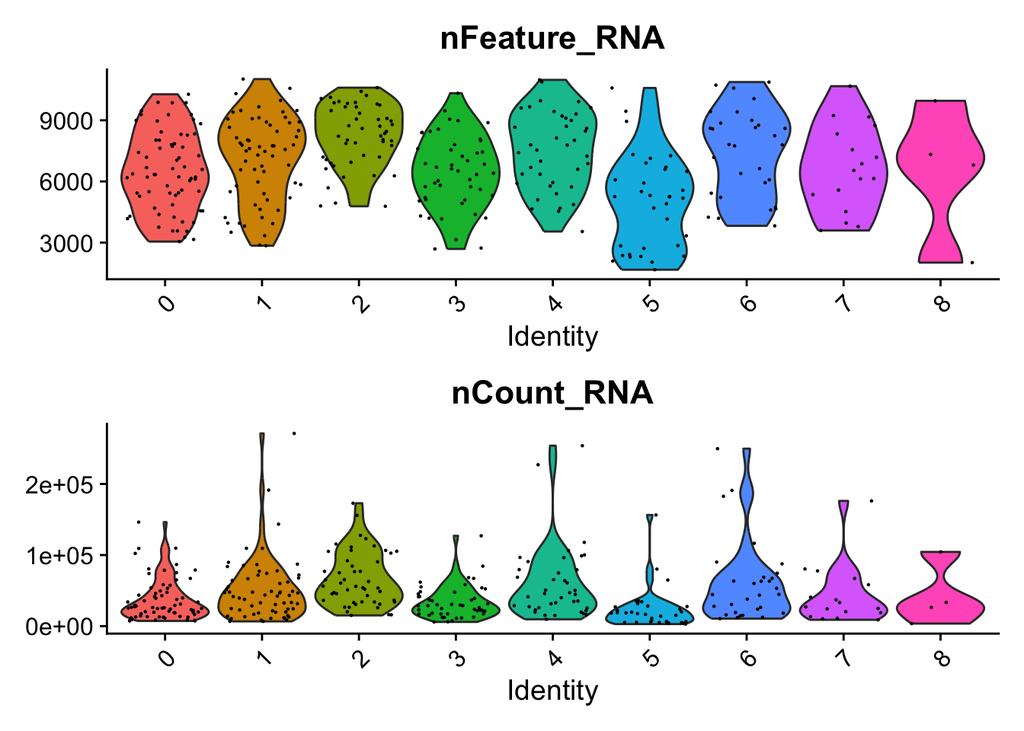

```r
VlnPlot(metaspot_seurat, features = c("nFeature_RNA", "nCount_RNA"), ncol = 1, group.by = "cluster_anno")
```

Save the MetaSpot Seurat object for downstream analysis!

```r
saveRDS(metaspot_seurat, file = "data/human_brain_cortex/Seurat_objects/Metaspots.rds")
```

Normalize data with SCTransform.

```r
options(future.globals.maxSize = 4 * 1024^3)
metaspot_seurat <- JoinLayers(metaspot_seurat)
metaspot_seurat_normalized <- SCTransform(metaspot_seurat,assay = "RNA",return.only.var.genes = T)
```

```r
metaspot_seurat_normalized
```

```
## An object of class Seurat
## 22762 features across 352 samples within 2 assays
## Active assay: SCT (11381 features, 3000 variable features)
##  3 layers present: counts, data, scale.data
##  1 other assay present: RNA
```

Save the normalized MetaSpot Seurat object for downstream analysis!

```r
saveRDS(metaspot_seurat_normalized, file = "data/human_brain_cortex/Seurat_objects/Metaspots_normalized.rds")
```